# Project CO2 - Bayesian Statistics

# Bayesian Statistical Analysis of CO2 Emissions Data

# Project tasks (to delete)

1. Consider a regression model to explain C02 emission with the other variables. You can transform some of the variables.
2. Additional questions: C02 and GDP are strongly dependent? Historically, CO2 emissions have been strongly correlated with how much money we have. This is particularly true at low-to-middle incomes. The richer we are, the more CO2 we emit. This is because we use more energy – which often comes from burning fossil fuels. This relationship is still true at higher incomes?
3. In addition you can: consider and compare various years. Consider the time as a covariate. Add more covariates (taking them from the web). Consider time series models.

# Introduction

Human emissions of carbon dioxide and other greenhouse gases are a primary driver of climate change and present one of the world’s most pressing challenges.

To understand this complex issue better our analysis will focus on:

1. **Long-Term Trends**: we will examine how CO2 emissions have evolved over the past century, identifying key periods of increase or decrease in the speed of emissions and correlating these with historical events.
2. **Recent Factors Influencing CO2 Emissions**: we will analyze the impact of various factors on CO2 emissions from 2006 to 2009. This includes investigating the relationship between CO2 emissions and variables such as energy consumption, GDP, and the adoption of low-carbon energy sources.
3. **Comparative Analysis**: We will compare findings from both datasets to understand how historical trends relate to more recent developments.

# Datasets

Brief description of the datasets:

- **Dataset 1** encompasses annual CO2 emissions for each year from 1900 to 2022. This dataset provides a comprehensive perspective on CO2 emissions over more than a century, allowing us to identify long-term trends and patterns.
- **Dataset 2** is more granular and concentrates on the years 2006 to 2009. It includes various features such as energy use per capita, GDP, population, CO2 emissions per capita, the percentage of low-carbon energy in total energy production, urbanization levels, and internet usage. This dataset allows for a detailed analysis of specific factors that may influence CO2 emissions during a recent, focused timeframe.

By integrating these two datasets, we aim to analyse CO2 emissions over time and identify the factors driving changes in recent years.

# Dataset 1

We begin our analysis by considering the long-term trends in annual CO2 emissions over the last century.

**Sources:**

https://ourworldindata.org/grapher/annual-co2-emissions-per-country

**Short description:**

Human emissions of carbon dioxide and other greenhouse gases between 1900 and 2022.

It includes data for various nations, encompassing the following variables:

- **country**: name of the country.
- **Code**: the code of each country
- **Year**: year.
- **AnnualCO2**: Annual CO2 emissions. [billion tons] (rescaled from tons)

```r
# Loading the data
CO2_full <- read.csv("Data/annual-co2-emissions-per-country.csv")
CO2_full$AnnualCO2 = CO2_full$AnnualCO2 /10^9
head(CO2_full)
```

|  | country | Code | Year | AnnualCO2 |
| --- | --- | --- | --- | --- |
| 1 | Afghanistan | AFG | 1949 | 0.000014656 |
| 2 | Afghanistan | AFG | 1950 | 0.000084272 |
| 3 | Afghanistan | AFG | 1951 | 0.000091600 |
| 4 | Afghanistan | AFG | 1952 | 0.000091600 |
| 5 | Afghanistan | AFG | 1953 | 0.000106256 |
| 6 | Afghanistan | AFG | 1954 | 0.000106256 |

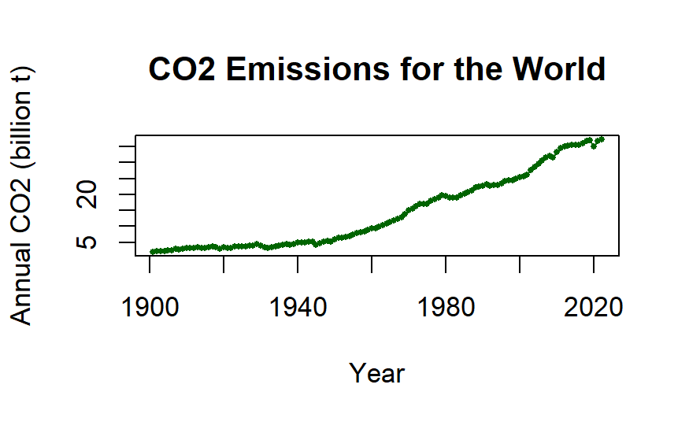

```r
# We filter the dataset for the world data after 1900
world_data <- CO2_full[CO2_full$country == 'World' & CO2_full$Year > 1900,]

# Plot
plot(world_data$Year, world_data$AnnualCO2, type='l', col='darkgreen', ylab="Annual CO2 (billion t)", main="CO2 Emissions for the World", xlab="Year")
points(world_data$Year, world_data$AnnualCO2, col='darkgreen', pch=16, cex=0.5)
```

The data presents a clear exponential trend, for this reason it could be interesting to analyse the **logarithm** of the data and see if we can find some interesting trends.

We will transform the CO2 in log_CO2 and also compute the **increment in log_CO2** i.e
$$x_t :=\log(y_{t+1})-\log(y_t)$$

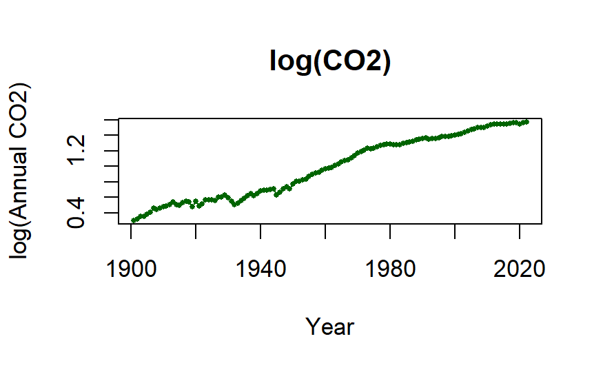

```r
# Creating the data
CO2_log = log(world_data$AnnualCO2, 10)
n1 = length(CO2_log)

delta_logdata = CO2_log[2:n1] - CO2_log[1:n1-1]
n2 = length(delta_logdata)

# Years
year = world_data$Year


# Plots
# Log data
plot(year, CO2_log, type='l', col='darkgreen', ylab="log(Annual CO2)", main="log(CO2)", xlab="Year")
points(year, CO2_log, col='darkgreen', pch=16, cex=0.5)
```

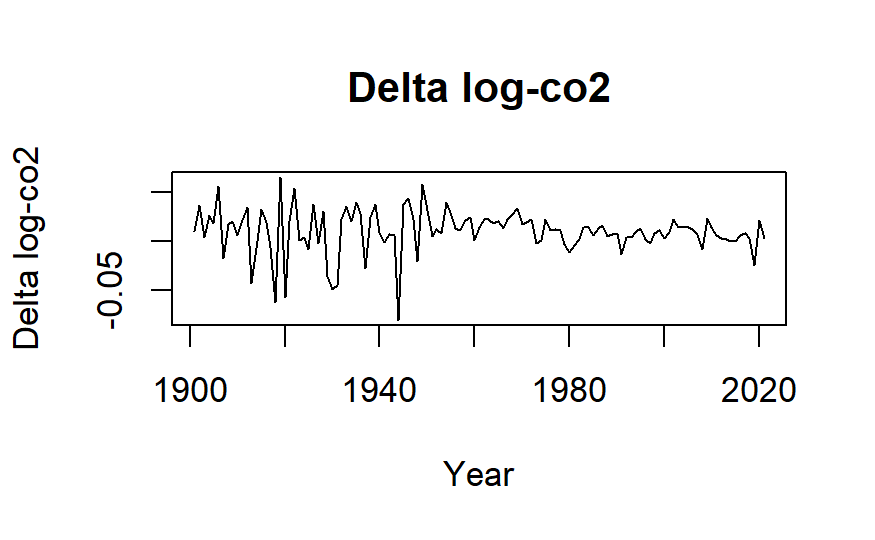

```r
# Delta log data
plot(year[1:length(delta_logdata)], delta_logdata, type='l', ylab="Delta log-co2", main="Delta log-co2", xlab="Year")
```

## Change point model for the variance

From the delta log-CO2 it is clear from the data that some kind of **shift on the variance** is happening.

To analyse this in more detail we will fit a change point model on the variance to our data.

We assume for our data a Gaussian likelihood:
$$y_t \sim \mathcal{N}(\mu_0,\sigma_t^2).$$
An event occurs at a random unobserved time $\tau$, the so-called “change point”.
This is reflected in the assumption
$$\sigma_t^2 =\sigma_{1}^2 \quad t < \tau$$
and
$$\sigma_t^2 =\sigma_{2}^2 \quad t \geq \tau$$
where $\sigma_1^2, \sigma_2^2$ are unknown.

The model is as follows:
$$\begin{split}
& y_t \sim \mathcal{N}(\mu_0,\sigma_t^2)\\
& \sigma_t^2 = \sigma_{1}^2 \{t < \tau \} + \sigma_2^2 \{ t \geq
\tau\} \\
& \tau \sim \mathcal{U}(0,M) \\
& \mu_0 \sim \mathcal{N}(0,100) \\
& \frac{1}{\sigma_i^2} \sim \mathcal{G}(0.001, 0.001) \ &i
\in [1, 2]
\end{split}$$
$M$ is a parameter that indicates the number of datapoints.

We choose the priors for $\mu_0$ and $\frac{1}{\sigma_i^2}$ to be weakly informative.

```r
library(rjags)
library(bayesplot)
library(jagsUI)
library(loo)

# change-point model
modelChangePoint <-
"model{
  # Likelihood
  for(i in 1:n){
    x[i] ~ dnorm(mu, sinv_CP[i])
    sinv_CP[i] <- sinv[J[i]]
    J[i] <- d[i] + 1         # move to (0,1) in (1,2)

  }

  # Mean change
  for(t in 1:n){
    d[t] <- step(Tau - t)
              # 0 if (agument < 0), 1 otherwise
              # Probabilities of the changing point to have happened
  }

  # Prior for d[i]
  Tau ~ dunif(1, n+10)

  # Prior for beta
  mu ~ dnorm(0, 0.01)
  sinv[1] ~ dgamma(0.001, 0.001)   # Non informative
  sinv[2] ~ dgamma(0.001, 0.001)
  # sinv[1] ~  dunif(0, 100000)   # Non informative
  # sinv[2] ~  dunif(0, 100000)

}"



# Data
myData = list(x=delta_logdata, n=length(delta_logdata))

# Jags
outputmcmcCP <- jags(model.file=textConnection(modelChangePoint),
                     data = myData,
                     parameters.to.save = c("mu", "sinv_CP", "Tau","J"),
                     n.adapt=1000, n.iter=20000, n.chains = 2, n.burnin = 2000)
```

[output not shown]

[output cut: 117 more lines]

[output not shown]

```r
# Output
outputmcmcCP
```

```
JAGS output for model '5', generated by jagsUI.
Estimates based on 2 chains of 20000 iterations,
adaptation = 1000 iterations (sufficient),
burn-in = 2000 iterations and thin rate = 1,
yielding 36000 total samples from the joint posterior.
MCMC ran for 0.089 minutes at time 2024-06-04 18:55:29.56004.
```

|  | mean | sd | 2.5% | 50% | 97.5% | overlap0 | f | Rhat | n.eff |
| --- | --- | --- | --- | --- | --- | --- | --- | --- | --- |
| mu | 0.011 | 0.001 | 0.008 | 0.011 | 0.013 | FALSE | 1 | 1.000 | 36000 |
| sinv_CP[1] | 929.556 | 186.197 | 603.035 | 918.986 | 1326.519 | FALSE | 1 | 1.000 | 36000 |
| sinv_CP[2] | 929.556 | 186.197 | 603.035 | 918.986 | 1326.519 | FALSE | 1 | 1.000 | 36000 |
| sinv_CP[3] | 929.556 | 186.197 | 603.035 | 918.986 | 1326.519 | FALSE | 1 | 1.000 | 36000 |
| sinv_CP[4] | 929.556 | 186.197 | 603.035 | 918.986 | 1326.519 | FALSE | 1 | 1.000 | 36000 |
| sinv_CP[5] | 929.556 | 186.197 | 603.035 | 918.986 | 1326.519 | FALSE | 1 | 1.000 | 36000 |
| sinv_CP[6] | 929.556 | 186.197 | 603.035 | 918.986 | 1326.519 | FALSE | 1 | 1.000 | 36000 |
| sinv_CP[7] | 929.556 | 186.197 | 603.035 | 918.986 | 1326.519 | FALSE | 1 | 1.000 | 36000 |
| sinv_CP[8] | 929.556 | 186.197 | 603.035 | 918.986 | 1326.519 | FALSE | 1 | 1.000 | 36000 |
| sinv_CP[9] | 929.556 | 186.197 | 603.035 | 918.986 | 1326.519 | FALSE | 1 | 1.000 | 36000 |

[output cut: 235 more lines]

```
**WARNING** Some Rhat values could not be calculated.
**WARNING** Rhat values indicate convergence failure.
Rhat is the potential scale reduction factor (at convergence, Rhat=1).
For each parameter, n.eff is a crude measure of effective sample size.

overlap0 checks if 0 falls in the parameter's 95% credible interval.
f is the proportion of the posterior with the same sign as the mean;
i.e., our confidence that the parameter is positive or negative.

DIC info: (pD = var(deviance)/2)
pD = 8 and DIC = -627.93
DIC is an estimate of expected predictive error (lower is better).
```

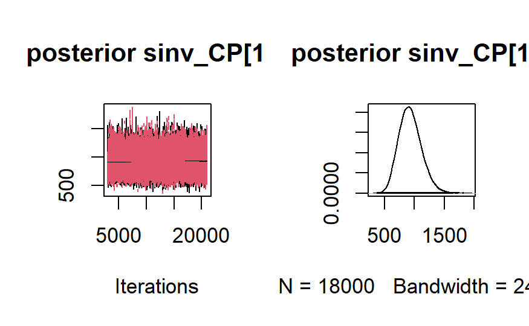

```r
# Trace and density
plot(outputmcmcCP$samples[,c("sinv_CP[10]")], main="posterior sinv_CP[10]")
```

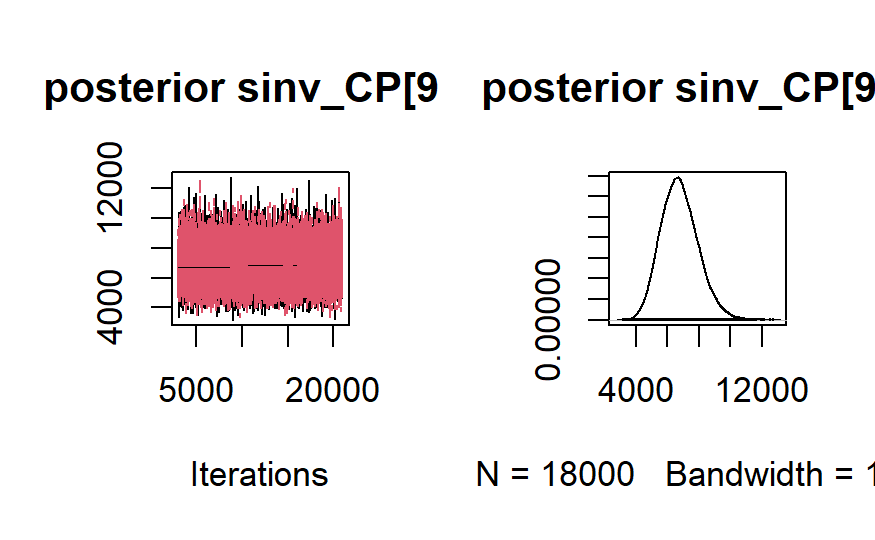

```r
plot(outputmcmcCP$samples[,c("sinv_CP[90]")], main="posterior sinv_CP[90]")
```

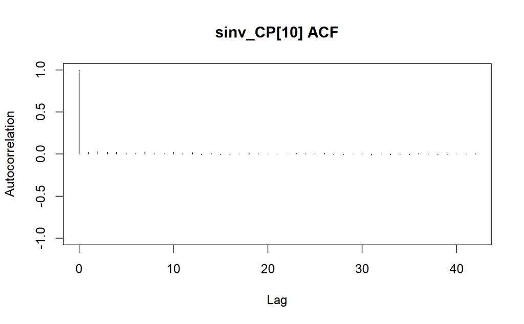

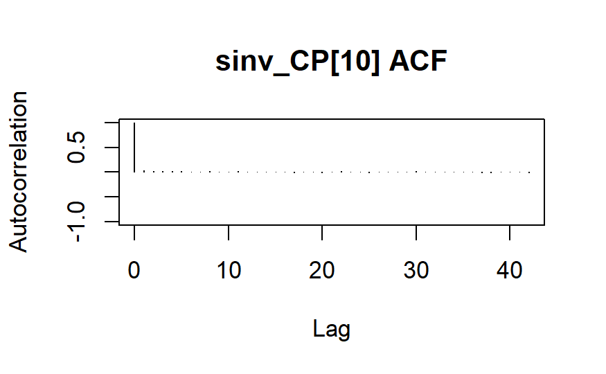

```r
# Autocorrelation function:
autocorr.plot(outputmcmcCP$samples[,c("sinv_CP[10]")], main= "sinv_CP[10] ACF")
```

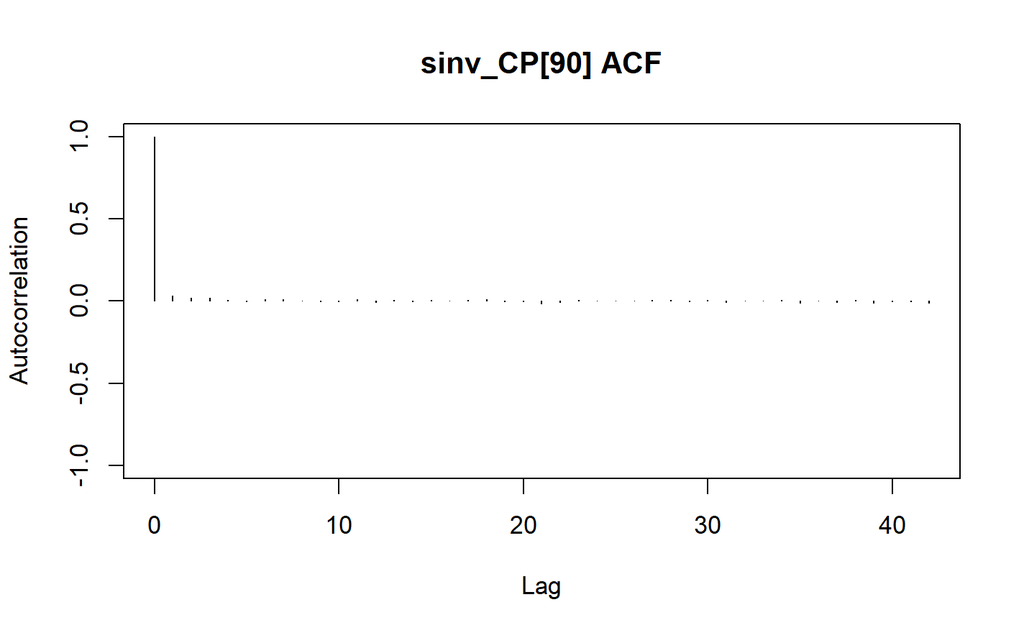

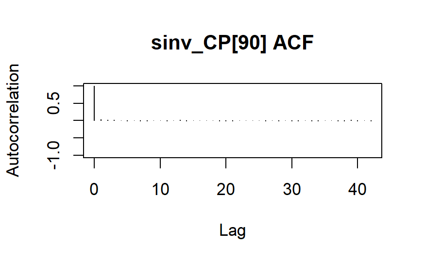

```r
autocorr.plot(outputmcmcCP$samples[,c("sinv_CP[90]")], main= "sinv_CP[90] ACF")
```

```r
# Selecting the taus
tau_samples = outputmcmcCP$samples[[1]][, "Tau"]

# Calculate the mean
tmean <- mean(tau_samples)

# Calculate the 2.5% quantile
q1 <- quantile(tau_samples, probs = 0.05)

# Calculate the 97.5% quantile
q2 <- quantile(tau_samples, probs = 0.95)


# Finding the year corresponding to qi
year_q1 = year[floor(q1)]
year_q2 = year[floor(q2)]
year_tmean = year[floor(tmean)]



# Plot
plot(year[1:length(delta_logdata)], delta_logdata, type='l', ylab="Delta log-co2", main="Delta log-co2", xlab="Year")

# lines for the change point
abline(v=year_tmean, col="red", lwd=1.5)
```

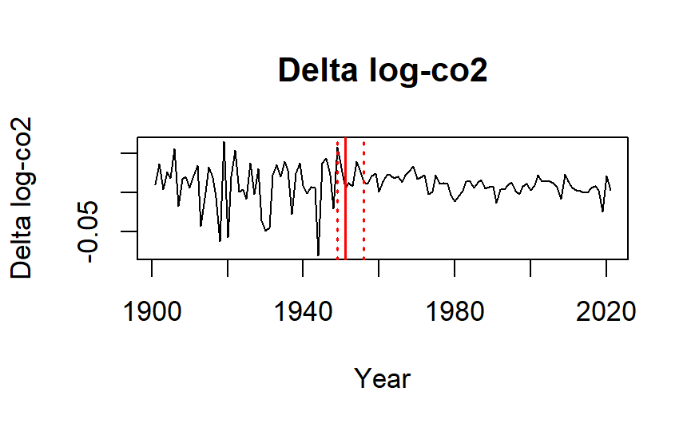

```r
abline(v=year_q1, col="red", lwd=1.5, lty = 3)
abline(v=year_q2, col="red", lwd=1.5, lty = 3)
```

```r
# Create a data frame to print the years
df <- data.frame(
  q1 = year_q1,
  Mean = year_tmean,
  q2 = year_q2
)
colnames(df) <- c("5%", "Mean", "95%")


# Print the data frame
print(df)
```

| 5% | Mean | 95% |
| --- | --- | --- |
| 1949 | 1951 | 1956 |

**Our analysis suggests a potential shift in the variance of the emission around 1951. With 90% confidence, we can say this shift likely occurred between 1949 and 1956.** This timeframe is particularly interesting because it coincides with several major events that could be linked to this change in trend:

- **The Marshall Plan (1948):** This large-scale U.S. program aimed to rebuild Europe after World War II. It likely spurred economic activity and potentially increased CO2 emissions.
- **The Post-War Economic Boom (1945-1973):** This period of rapid economic growth across the globe could have significantly contributed to rising emissions.

One possible interpretation of these findings is that improved economic conditions led to **both a decrease in the variability and an increase in the overall quantity of emissions**. This suggests a shift towards more consistent, but higher, emissions during this time.

**Credible Interval:** When you specify a range between the 5th percentile and the 95th percentile of the posterior distribution, you are describing a 90% credible interval. A credible interval gives a range within which the true parameter is believed to lie with a certain probability, according to the posterior distribution.

## Change Point model for the mean

**Given the potential shift in CO2 emission patterns around 1951, a next step could be to investigate if there are further changes in trend following this period.** The Post-War Economic Boom ended with a recession (1973-1975), followed by an even deeper one in the early 1980s. This historical context prompts the question: **Can we detect another change point in the CO2 emissions data after 1951?**

For the next analysis we will try to fit the data after the first shift (1951) with a change point model on the mean of the delta log-co2 in the years after 1956 (95% quantile of the change point on the variance). This means that we will analyse the change in speed of the increase of CO2 (mean of the logarithm) and not its variance anymore.

The model is as follows:
$$\begin{split}
& y_t \stackrel{ind}{\sim} \mathcal{N}(\mu_t,\sigma_{0}^2)\\
& \mu_t=\mu_1 \{t < \tau \} + \mu_2 \{ t \geq \tau\} \\
& \tau \sim \mathcal{U}(0,M) \\
& \mu_1 \sim \mathcal{N}(5,100) \\
& \mu_2 \sim \mathcal{N}(0,100) \\
& \frac{1}{\sigma^2} \sim \mathcal{U}(0, 100000)
\end{split}$$
$M$ is a parameter that indicates the number of datapoints.

We choose the priors for $\mu_0$ and $\frac{1}{\sigma^2}$ to be weakly informative.

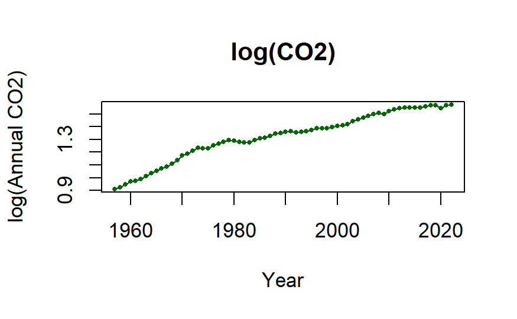

```r
# Filtering for data after the change point
# !!! The data is after 1956 (even if the variable has a 51 in the name)
world_data_after1951 <- world_data[world_data$Year > 1956,]


# Creating the data
CO2_log_51 = log(world_data_after1951$AnnualCO2, 10)
n1 = length(CO2_log_51)

delta_logdata_51 = CO2_log_51[2:n1] - CO2_log_51[1:n1-1]
n2 = length(delta_logdata)

# Years
year = world_data_after1951$Year


# Plots
plot(year, CO2_log_51, type='l', col='darkgreen', ylab="log(Annual CO2)", main="log(CO2)", xlab="Year")
points(year, CO2_log_51, col='darkgreen', pch=16, cex=0.5)
```

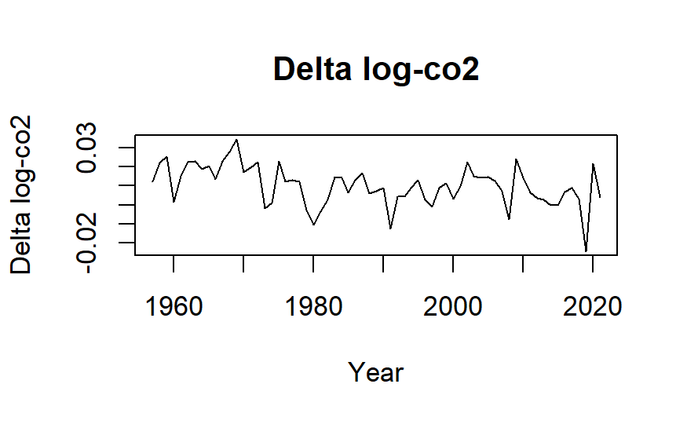

```r
# Delta log data
plot(year[1:length(delta_logdata_51)], delta_logdata_51, type='l', ylab="Delta log-co2", main="Delta log-co2", xlab="Year")
```

```r
# change-point model
modelChangePoint_mean <-
"model{
  # Likelihood
  for(i in 1:n){
    x[i] ~ dnorm(mu[i], sinv)
    mu[i] <- m[J[i]]
    J[i] <- d[i] + 1         # move to (0,1) in (1,2)
  }

  # Mean change
  for(t in 1:n){
    d[t] <- step(Tau - t)   # probabilities of the changing point to have happened
  }

  # Prior for d[i]
  Tau ~ dunif(1, n+10)

  # Prior for beta
  m[1] ~ dnorm(5, 0.01)
  m[2] ~ dnorm(0, 0.01)
  sinv ~ dunif(0, 100000)         # This is more stable that a Gamma

}"


# Data
myData = list(x=delta_logdata_51, n=length(delta_logdata_51))

# Jags
outputmcmcCP <- jags(model.file=textConnection(modelChangePoint_mean),
                     data = myData,
                     parameters.to.save = c("mu", "sinv", "Tau","J"),
                     n.adapt=1000, n.iter=20000, n.chains = 2, n.burnin = 2000,
                     n.thin = 1)
```

[output not shown]

[output cut: 117 more lines]

[output not shown]

```r
# Output
outputmcmcCP
```

```
JAGS output for model '4', generated by jagsUI.
Estimates based on 2 chains of 20000 iterations,
adaptation = 1000 iterations (sufficient),
burn-in = 2000 iterations and thin rate = 1,
yielding 36000 total samples from the joint posterior.
MCMC ran for 0.058 minutes at time 2024-06-04 18:55:37.871628.
```

|  | mean | sd | 2.5% | 50% | 97.5% | overlap0 | f | Rhat | n.eff |
| --- | --- | --- | --- | --- | --- | --- | --- | --- | --- |
| mu[1] | 0.019 | 0.002 | 0.014 | 0.019 | 0.024 | FALSE | 1 | 1.000 | 4661 |
| mu[2] | 0.019 | 0.002 | 0.014 | 0.019 | 0.024 | FALSE | 1 | 1.000 | 4661 |
| mu[3] | 0.019 | 0.002 | 0.014 | 0.019 | 0.024 | FALSE | 1 | 1.000 | 4661 |
| mu[4] | 0.019 | 0.002 | 0.014 | 0.019 | 0.024 | FALSE | 1 | 1.000 | 4661 |
| mu[5] | 0.019 | 0.002 | 0.014 | 0.019 | 0.024 | FALSE | 1 | 1.000 | 4661 |
| mu[6] | 0.019 | 0.002 | 0.014 | 0.019 | 0.024 | FALSE | 1 | 1.000 | 4661 |
| mu[7] | 0.019 | 0.002 | 0.014 | 0.019 | 0.024 | FALSE | 1 | 1.000 | 4661 |
| mu[8] | 0.019 | 0.002 | 0.014 | 0.019 | 0.024 | FALSE | 1 | 1.000 | 4713 |
| mu[9] | 0.019 | 0.002 | 0.014 | 0.019 | 0.024 | FALSE | 1 | 1.000 | 4551 |
| mu[10] | 0.019 | 0.002 | 0.014 | 0.019 | 0.024 | FALSE | 1 | 1.000 | 4586 |

[output cut: 123 more lines]

```
**WARNING** Some Rhat values could not be calculated.
**WARNING** Rhat values indicate convergence failure.
Rhat is the potential scale reduction factor (at convergence, Rhat=1).
For each parameter, n.eff is a crude measure of effective sample size.

overlap0 checks if 0 falls in the parameter's 95% credible interval.
f is the proportion of the posterior with the same sign as the mean;
i.e., our confidence that the parameter is positive or negative.

DIC info: (pD = var(deviance)/2)
pD = 6.3 and DIC = -419.423
DIC is an estimate of expected predictive error (lower is better).
```

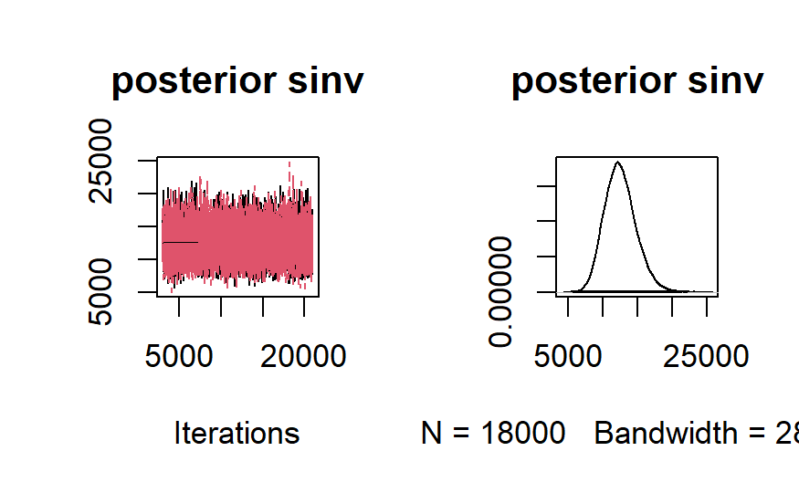

```r
# Trace and density
plot(outputmcmcCP$samples[,c("sinv")], main="posterior sinv")
```

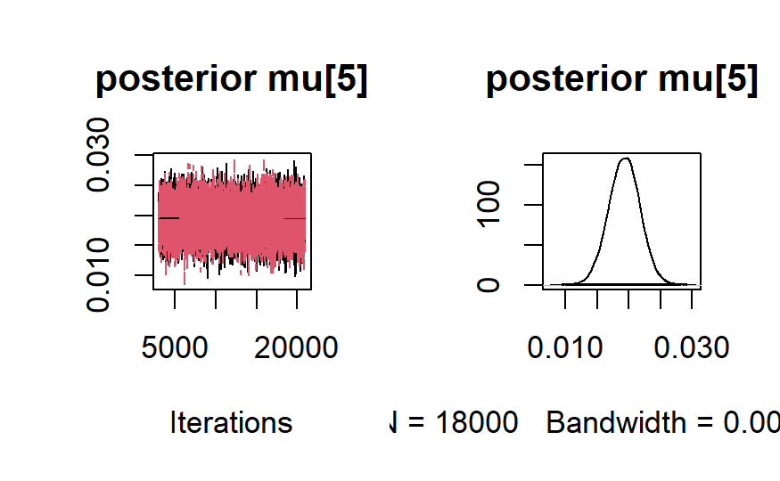

```r
plot(outputmcmcCP$samples[,c("mu[5]")], main="posterior mu[5]")
```

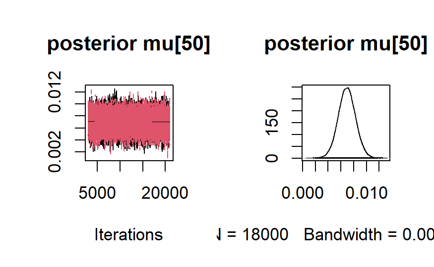

```r
plot(outputmcmcCP$samples[,c("mu[50]")], main="posterior mu[50]")
```

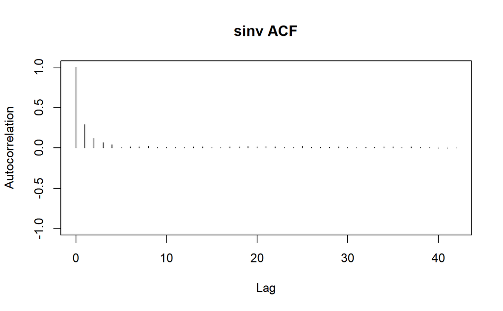

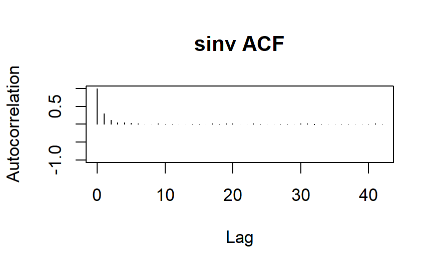

```r
# Autocorrelation
autocorr.plot(outputmcmcCP$samples[,c("sinv")], main= "sinv ACF")
```

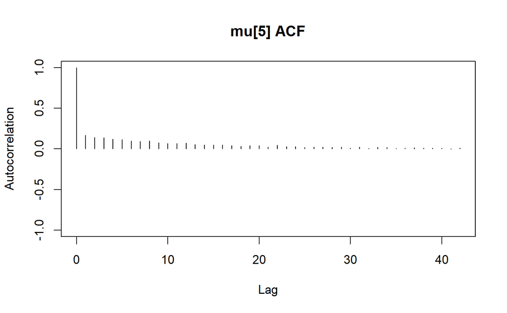

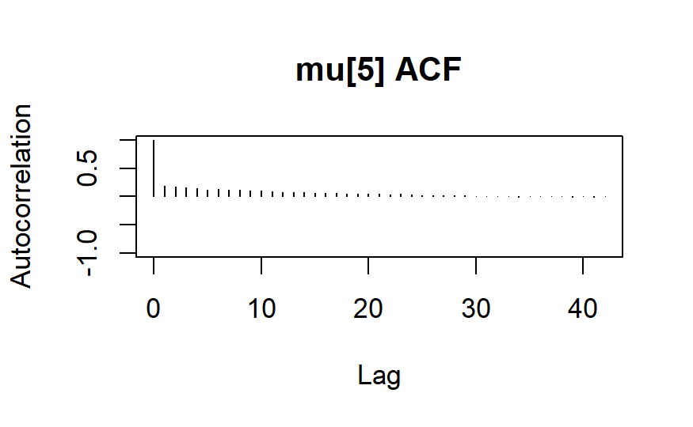

```r
autocorr.plot(outputmcmcCP$samples[,c("mu[5]")], main="mu[5] ACF")
```

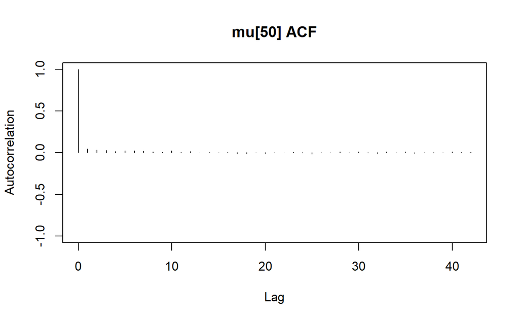

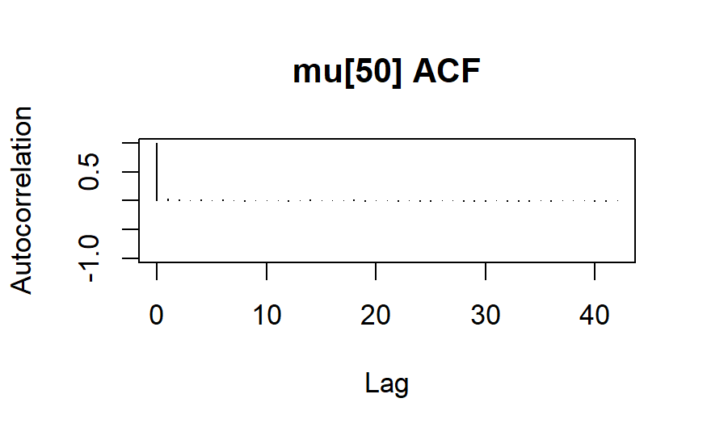

```r
autocorr.plot(outputmcmcCP$samples[,c("mu[50]")], main="mu[50] ACF")
```

```r
# Selecting the tau samples
tau_samples = outputmcmcCP$samples[[1]][, "Tau"]

# Calculate the mean
tmean <- mean(tau_samples)

# Calculate the 2.5% quantile
q1 <- quantile(tau_samples, probs = 0.05)

# Calculate the 97.5% quantile
q2 <- quantile(tau_samples, probs = 0.95)


# Finding the year corresponding to qi
year_q1 = year[floor(q1)]
year_q2 = year[floor(q2)]
year_tmean = year[floor(tmean)]



# Plot
plot(year[1:length(delta_logdata_51)], delta_logdata_51, type='l', ylab="Delta log-co2", main="Delta log-co2", xlab="Year")

# lines for the change point
abline(v=year_tmean, col="red", lwd=1.5)
```

```r
abline(v=year_q1, col="red", lwd=1.5, lty = 3)
abline(v=year_q2, col="red", lwd=1.5, lty = 3)
```

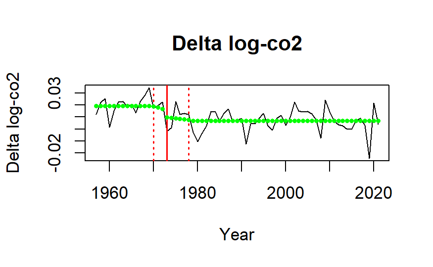

```r
# Sampled mean
ssCP2 = summary(outputmcmcCP)
n2 = length(delta_logdata_51)
points(year[1:n2], ssCP2[1:n2,"mean"], col="green", pch=16, cex=0.6)
```

```r
# Create a data frame to print the years
df <- data.frame(
  q1 = year_q1,
  Mean = year_tmean,
  q2 = year_q2
)
colnames(df) <- c("5%", "Mean", "95%")


# Print the data frame
print(df)
```

| 5% | Mean | 95% |
| --- | --- | --- |
| 1970 | 1973 | 1978 |

As we can see from the plots we can indeed spot a change in the mean of our model around 1973, **with** **a 90% chance this change occurred between 1970 and 1978.**

An interpretation of this finding could be that the worsened economic conditions caused by the economic recessions of that era may have contributed to a slowdown in CO2 emissions growth.

### Regressions over the change points

**Our analysis identified two potential turning points in the CO2 emission trend: 1951 and 1973.** To gain a clearer visual understanding of these shifts, we’ll segment the data into three periods: **before**, **between**, and **after** these critical years. **By fitting regression lines to the log of CO2 emissions for each period, we can directly visualize the changes** in the emissions trajectory.

```r
# Adding a columns for the log data
world_data$CO2_log = CO2_log

# Filtering for data up untile 1975 (End of the Post-War Economic Boom)
world_data_before1973 <- world_data[world_data$Year < 1973,]
world_data_after1973 <- world_data[world_data$Year > 1973,]


# Splitting the data in 'before' and 'after' the change-point
world_data_before1951 <- world_data_before1973[world_data_before1973$Year < 1951,]
world_data_after1951 <- world_data_before1973[world_data_before1973$Year > 1951,]


# Fitting some linear models
world_data_before1951.lm = lm(CO2_log ~ Year, data = world_data_before1951)
world_data_after1951.lm = lm(CO2_log ~ Year, data = world_data_after1951)
world_data_after1973.lm = lm(CO2_log ~ Year, data = world_data_after1973)

#Plots
plot(world_data$Year, world_data$CO2_log, type='l', col='darkgreen', ylab="log(Annual CO2)", main="log(CO2)", xlab="Year")
points(world_data$Year, world_data$CO2_log, col='darkgreen', pch=16, cex=0.5)
```

```r
# Lines
beta_before_1951 = coef(world_data_before1951.lm)
beta_after_1951 = coef(world_data_after1951.lm)
beta_after_1973 = coef(world_data_after1973.lm)
abline(beta_before_1951, col='red', lty=3)
abline(beta_after_1951, col='green', lty=3)
```

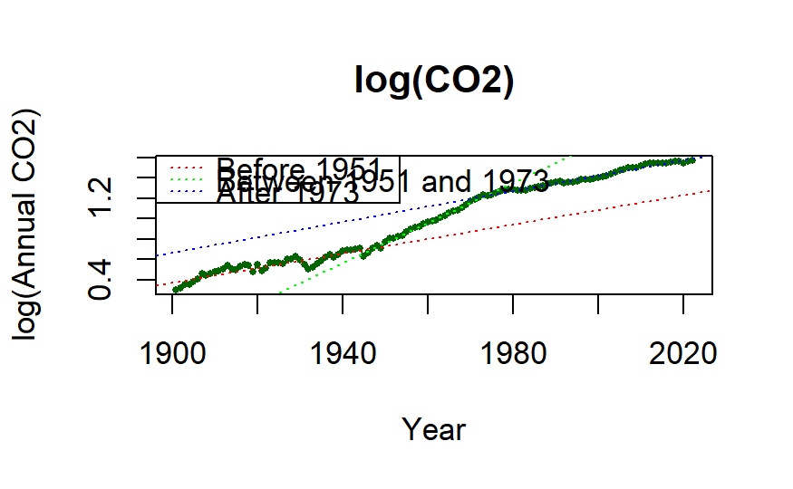

```r
abline(beta_after_1973, col='blue', lty=3)


# Legend
legend("topleft", legend=c("Before 1951", "Between 1951 and 1973", "After 1973"), col=c("red", "green", "blue"), lty=3)
```

```r
# Plot 2
plot(world_data$Year, world_data$AnnualCO2, type='l', col='darkgreen', ylab="Annual CO2 (billion t)", main="CO2 Emissions for the World", xlab="Year")
points(world_data$Year, world_data$AnnualCO2, col='darkgreen', pch=16, cex=0.5)
```

```r
# # Add a vertical line in the two change points
abline(v = 1951, col = "red", lwd = 1, lty = 3)
abline(v = 1973, col = "green", lwd = 1, lty = 3)
```

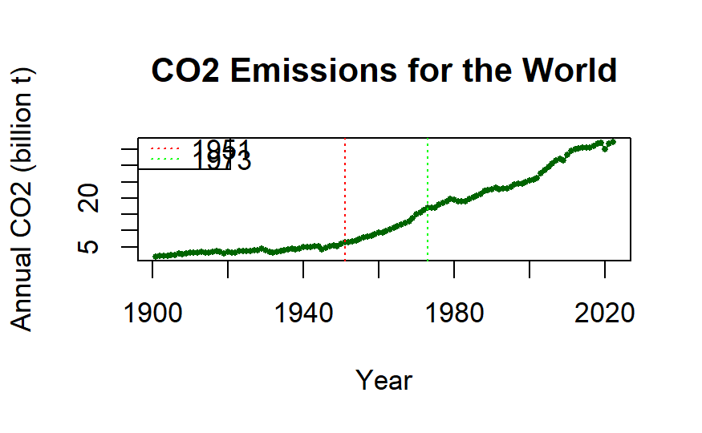

```r
legend("topleft", legend=c("1951", "1973"), col=c("red", "green"), lty=3)
```

As we can see from the plots there is a clear shift in the speed of increase of emissions before and after the change points.

## AR(1) model - Time series prediction

Building on the identified change points in CO2 emissions, a crucial next step is to explore what lies ahead.

The current estimate (2023) for the world’s remaining carbon budget for a 50% chance to stay under 1.5 °C (2.7 °F) is **250 gigatonnes CO2**.

**Can we predict when we might reach a critical level of CO2 emissions that would push global temperatures 1.5°C above pre-industrial levels?**

We will carry on this analysis by fitting an **AR(1)** model with parameters $\mu,\alpha$ and $\sigma^2$ to the delta of the logarithm of CO2 emissions on data after 1978 (95% that the change point has happened).

We assume the following priors:
$$\begin{split}
& \alpha \sim \mathcal{U}(-1,1) \\
& \mu\sim \mathcal{N}(0,10) \\
& \tau=\frac{1}{\sigma^2} \sim \mathcal{G}(0.001,0.001)
\end{split}$$

We choose the priors for $\mu$ and $\frac{1}{\sigma^2}$ to be weakly informative.

```r
# Ar(1)
modelAR.string <-"model {
  ## parameters: alpha, tau, m0
  # likeliohood
  mu[1] <- Y[1]

  for (i in 2:N) {
    Y[i] ~ dnorm(mu[i], tau)
    mu[i] <- m0 + alpha * Y[i-1]
  }

  # prediction out of sample
  ypOut[1] = Y[N]                   # The first sample is Y[N]!!!
  ypOut[2] ~ dnorm(m0 + alpha * Y[N], tau)
  for(k in 3:Npred){
    ypOut[k] ~ dnorm(m0 + alpha * ypOut[k-1], tau)
  }


  # prior
  # alpha ~ dnorm(0.0, 1)
  alpha ~ dunif(-1, 1)
  tau ~ dgamma(0.001, 0.001)        # weakly informative prior
  m0 ~ dnorm(0.0, 0.1)
  sigma2 <- 1 / tau
}"



# Filtering the data
world_data_after1978 <- world_data[world_data$Year > 1978,]

CO2_log_78 = log(world_data_after1978$AnnualCO2, 10)
n1 = length(CO2_log_78)

delta_logdata_78 = CO2_log_78[2:n1] - CO2_log_78[1:n1-1]
n2 = length(delta_logdata_78)

# Years
year_78 = world_data_after1978$Year



# Parameters
Npred = 9 + 1         # horizon for out-of-sample prediction



line_data <- list("Y"=delta_logdata_78, "N" = length(delta_logdata_78), "Npred"=Npred)

outputmcmcAR <- jags(model.file=textConnection(modelAR.string),
                     data = line_data,
                     parameters.to.save = c('alpha', "sigma2","m0","ypOut", "tau"),
                     n.adapt=1000, n.iter=20000, n.chains = 2, n.burnin = 2000,
                     n.thin = 5)
```

[output not shown]

[output cut: 117 more lines]

[output not shown]

```r
# Output
outputmcmcAR
```

```
JAGS output for model '6', generated by jagsUI.
Estimates based on 2 chains of 20000 iterations,
adaptation = 1000 iterations (sufficient),
burn-in = 2000 iterations and thin rate = 5,
yielding 7200 total samples from the joint posterior.
MCMC ran for 0.011 minutes at time 2024-06-04 18:55:44.169105.
```

|  | mean | sd | 2.5% | 50% | 97.5% | overlap0 | f | Rhat | n.eff |
| --- | --- | --- | --- | --- | --- | --- | --- | --- | --- |
| alpha | 0.091 | 0.199 | -0.300 | 0.088 | 0.480 | TRUE | 0.684 | 1.000 | 7200 |
| sigma2 | 0.000 | 0.000 | 0.000 | 0.000 | 0.000 | FALSE | 1.000 | 1.000 | 1 |
| m0 | 0.006 | 0.002 | 0.002 | 0.006 | 0.011 | FALSE | 0.995 | 1.000 | 7200 |
| ypOut[1] | 0.004 | 0.000 | 0.004 | 0.004 | 0.004 | FALSE | 1.000 | NA | 1 |
| ypOut[2] | 0.006 | 0.012 | -0.018 | 0.006 | 0.031 | TRUE | 0.699 | 1.000 | 7200 |
| ypOut[3] | 0.007 | 0.013 | -0.018 | 0.007 | 0.032 | TRUE | 0.701 | 1.000 | 7200 |
| ypOut[4] | 0.007 | 0.013 | -0.019 | 0.007 | 0.031 | TRUE | 0.696 | 1.000 | 7200 |
| ypOut[5] | 0.007 | 0.013 | -0.018 | 0.007 | 0.031 | TRUE | 0.701 | 1.000 | 7200 |
| ypOut[6] | 0.007 | 0.013 | -0.018 | 0.007 | 0.032 | TRUE | 0.716 | 1.000 | 6396 |
| ypOut[7] | 0.007 | 0.013 | -0.019 | 0.007 | 0.032 | TRUE | 0.708 | 1.001 | 7200 |

[output cut: 5 more lines]

```
**WARNING** Some Rhat values could not be calculated.
Successful convergence based on Rhat values (all < 1.1).
Rhat is the potential scale reduction factor (at convergence, Rhat=1).
For each parameter, n.eff is a crude measure of effective sample size.

overlap0 checks if 0 falls in the parameter's 95% credible interval.
f is the proportion of the posterior with the same sign as the mean;
i.e., our confidence that the parameter is positive or negative.

DIC info: (pD = var(deviance)/2)
pD = 9.8 and DIC = -256.802
DIC is an estimate of expected predictive error (lower is better).
```

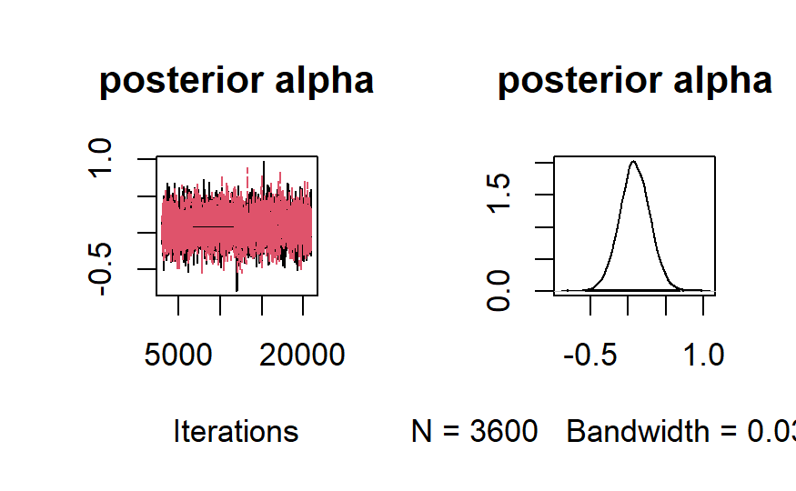

```r
# Trace and density
plot(outputmcmcAR$samples[,c('alpha')], main="posterior alpha")
```

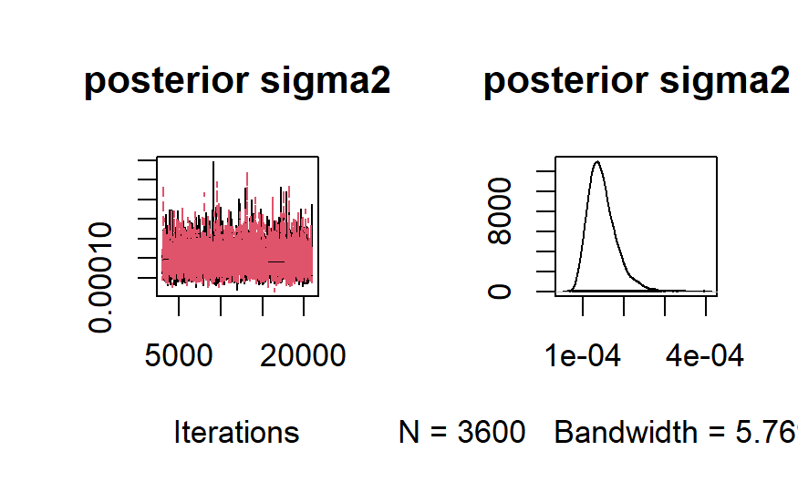

```r
plot(outputmcmcAR$samples[,c('sigma2')], main="posterior sigma2")
```

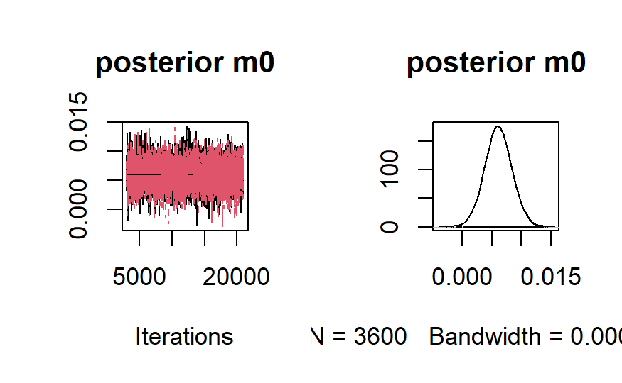

```r
plot(outputmcmcAR$samples[,c('m0')], main="posterior m0")
```

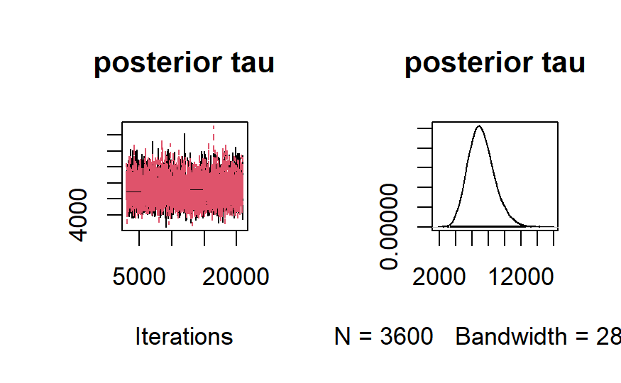

```r
plot(outputmcmcAR$samples[,c('tau')], main="posterior tau")
```

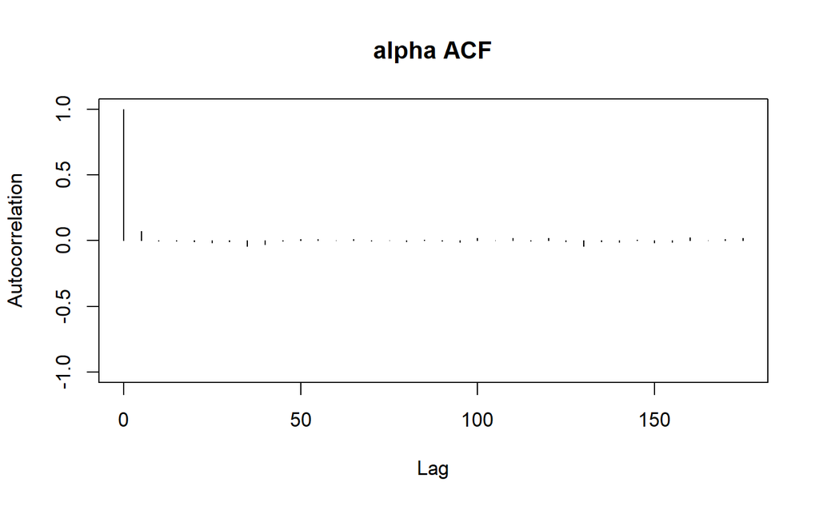

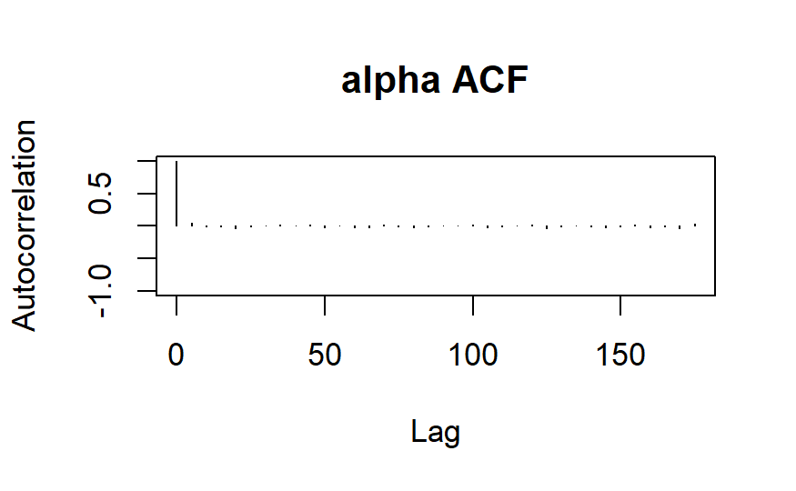

```r
# Autocorrelation
autocorr.plot(outputmcmcAR$samples[,c('alpha')], main= "alpha ACF")
```

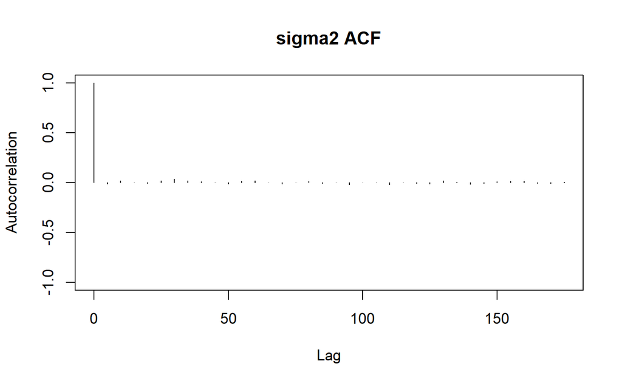

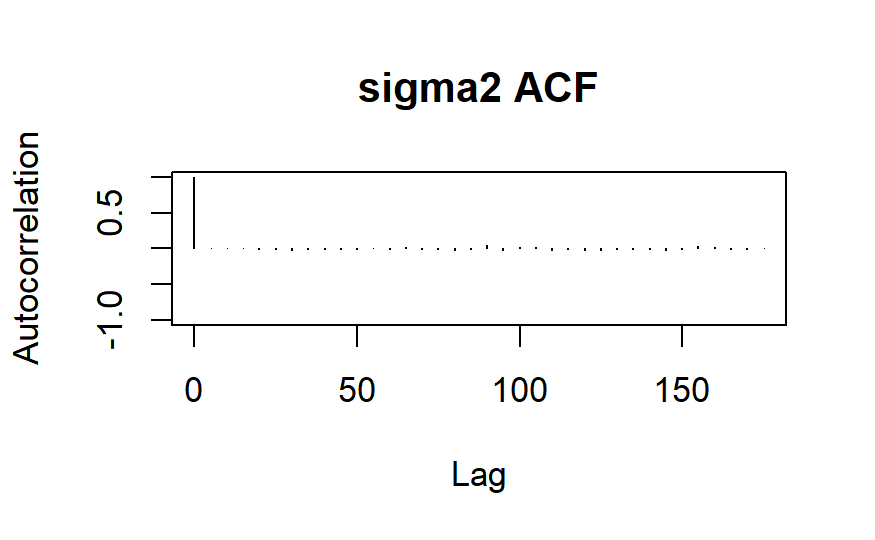

```r
autocorr.plot(outputmcmcAR$samples[,c('sigma2')], main= "sigma2 ACF")
```